[figure not shown]

[figure not shown]

# Model fit

### Assumption checks

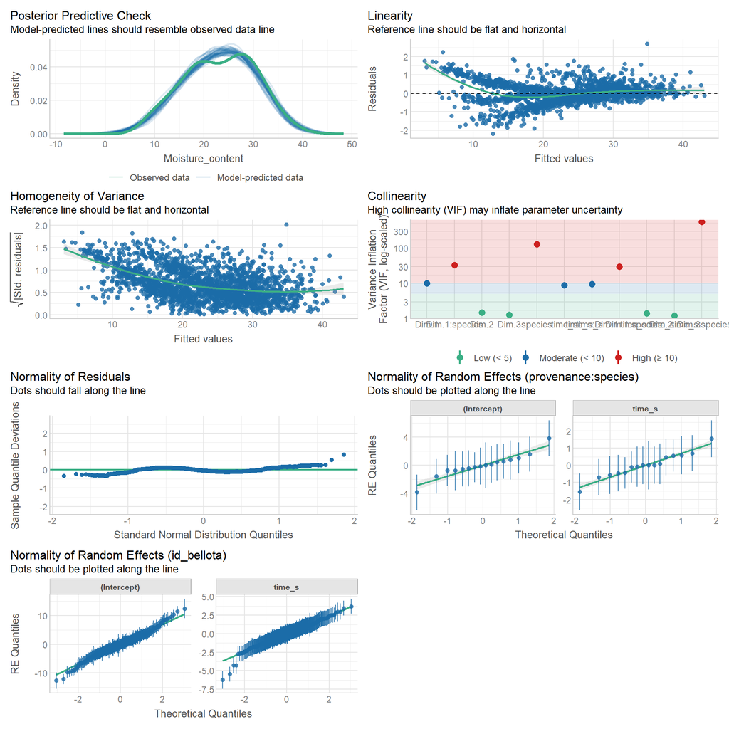

### Indices of model fit

| Metric | Value |
| --- | --- |
| AIC | 7751.0 |
| AICc | 7752.7 |
| BIC | 7996.5 |
| R2 (cond.) | 0.99 |
| R2 (marg.) | 0.69 |
| ICC | 0.97 |
| RMSE | 0.53 |
| Sigma | 0.66 |

For interpretation of performance metrics, please refer to [this documentation](https://easystats.github.io/performance/reference/model_performance.html).

# Parameter estimates

### Plot

[figure not shown]

### Tabular summary

Fixed Effects

| Parameter | Coefficient | SE | 95% CI | z | p |
| --- | --- | --- | --- | --- | --- |
| (Intercept) | 29.12 | 1.35 | (26.47, 31.77) | 21.51 | < .001 |
| time s | -8.55 | 0.57 | (-9.67, -7.43) | -14.96 | < .001 |
| Dim 1 | 0.53 | 0.43 | (-0.32, 1.37) | 1.22 | 0.224 |
| Dim 2 | -0.61 | 0.22 | (-1.04, -0.17) | -2.75 | 0.006 |
| Dim 3 | -0.40 | 0.22 | (-0.82, 0.02) | -1.85 | 0.064 |
| species (Quercus faginea) | -0.70 | 1.96 | (-4.53, 3.14) | -0.36 | 0.721 |
| species (Quercus ilex) | 2.63 | 1.71 | (-0.71, 5.98) | 1.54 | 0.123 |
| species (Quercus petraea) | -0.34 | 1.94 | (-4.13, 3.46) | -0.17 | 0.863 |
| species (Quercus pubescens) | -0.22 | 2.39 | (-4.89, 4.46) | -0.09 | 0.927 |
| species (Quercus pyrenaica) | 1.72 | 1.99 | (-2.19, 5.62) | 0.86 | 0.389 |
| species (Quercus robur) | 3.66 | 1.87 | (7.19e-03, 7.32) | 1.96 | 0.050 |
| species (Quercus suber) | -0.04 | 2.01 | (-3.98, 3.89) | -0.02 | 0.982 |
| time s × Dim 1 | 0.05 | 0.17 | (-0.28, 0.38) | 0.29 | 0.774 |
| time s × Dim 2 | -0.05 | 0.09 | (-0.22, 0.12) | -0.61 | 0.543 |
| time s × Dim 3 | 0.04 | 0.08 | (-0.13, 0.20) | 0.43 | 0.667 |
| time s × species (Quercus faginea) | 1.49 | 0.82 | (-0.12, 3.11) | 1.82 | 0.069 |
| time s × species (Quercus ilex) | 1.53 | 0.72 | (0.11, 2.94) | 2.11 | 0.035 |
| time s × species (Quercus petraea) | -0.96 | 0.82 | (-2.56, 0.63) | -1.18 | 0.237 |
| time s × species (Quercus pubescens) | 1.05 | 1.00 | (-0.92, 3.01) | 1.04 | 0.297 |
| time s × species (Quercus pyrenaica) | 1.54 | 0.84 | (-0.10, 3.18) | 1.84 | 0.065 |
| time s × species (Quercus robur) | 2.46 | 0.79 | (0.91, 4.00) | 3.11 | 0.002 |
| time s × species (Quercus suber) | -1.19 | 0.84 | (-2.84, 0.46) | -1.41 | 0.157 |
| Dim 1 × species (Quercus faginea) | 0.22 | 0.72 | (-1.20, 1.63) | 0.30 | 0.764 |
| Dim 1 × species (Quercus ilex) | -0.15 | 0.55 | (-1.23, 0.93) | -0.27 | 0.785 |
| Dim 1 × species (Quercus petraea) | 1.47 | 0.59 | (0.32, 2.61) | 2.51 | 0.012 |
| Dim 1 × species (Quercus pubescens) | 1.58 | 0.81 | (-0.01, 3.17) | 1.94 | 0.052 |
| Dim 1 × species (Quercus pyrenaica) | -0.79 | 0.56 | (-1.89, 0.31) | -1.41 | 0.158 |
| Dim 1 × species (Quercus robur) | 0.32 | 0.66 | (-0.97, 1.61) | 0.48 | 0.629 |
| Dim 1 × species (Quercus suber) | -0.80 | 0.65 | (-2.07, 0.47) | -1.23 | 0.218 |
| (time s × Dim 1) × species (Quercus faginea) | 0.70 | 0.28 | (0.14, 1.25) | 2.45 | 0.014 |
| (time s × Dim 1) × species (Quercus ilex) | 0.61 | 0.21 | (0.20, 1.03) | 2.89 | 0.004 |
| (time s × Dim 1) × species (Quercus petraea) | 0.08 | 0.23 | (-0.36, 0.52) | 0.35 | 0.723 |
| (time s × Dim 1) × species (Quercus pubescens) | 0.23 | 0.31 | (-0.39, 0.84) | 0.73 | 0.467 |
| (time s × Dim 1) × species (Quercus pyrenaica) | 0.15 | 0.22 | (-0.27, 0.58) | 0.71 | 0.477 |
| (time s × Dim 1) × species (Quercus robur) | 0.42 | 0.25 | (-0.08, 0.92) | 1.66 | 0.097 |
| (time s × Dim 1) × species (Quercus suber) | 0.44 | 0.25 | (-0.06, 0.93) | 1.73 | 0.084 |

Random Effects

| Parameter | Coefficient |
| --- | --- |
| SD (Intercept: provenance:species) | 1.66 |
| SD (Intercept: id_bellota) | 3.57 |
| SD (time_s: provenance:species) | 0.72 |
| SD (time_s: id_bellota) | 1.31 |
| Cor (Intercept~time_s: provenance:species) | -0.74 |
| Cor (Intercept~time_s: id_bellota) | -0.04 |
| SD (Residual) | 0.66 |

To find out more about table summary options, please refer to [this documentation](https://easystats.github.io/parameters/reference/model_parameters.html).

# Predicted Values

### Plot

[output not shown]

# Text reports

### Textual summary

We fitted a linear mixed model (estimated using ML and nlminb optimizer) to predict Moisture_content with time_s, Dim.1, Dim.2, Dim.3 and species (formula: Moisture_content ~ time_s * (Dim.1 + Dim.2 + Dim.3) + time_s * Dim.1 * species). The model included time_s as random effects (formula: list(~time_s | provenance:species, ~time_s | id_bellota)). The model’s total explanatory power is substantial (conditional R2 = 0.99) and the part related to the fixed effects alone (marginal R2) is of 0.69. The model’s intercept, corresponding to time_s = 0, Dim.1 = 0, Dim.2 = 0, Dim.3 = 0 and species = Quercus coccifera, is at 29.12 (95% CI (26.47, 31.77), p < .001). Within this model:

- The effect of time s is statistically significant and negative (beta = -8.55, 95% CI (-9.67, -7.43), p < .001)
- The effect of Dim 1 is statistically non-significant and positive (beta = 0.53, 95% CI (-0.32, 1.37), p = 0.224)
- The effect of Dim 2 is statistically significant and negative (beta = -0.61, 95% CI (-1.04, -0.17), p = 0.006)
- The effect of Dim 3 is statistically non-significant and negative (beta = -0.40, 95% CI (-0.82, 0.02), p = 0.064)
- The effect of species (Quercus faginea) is statistically non-significant and negative (beta = -0.70, 95% CI (-4.53, 3.14), p = 0.721)
- The effect of species (Quercus ilex) is statistically non-significant and positive (beta = 2.63, 95% CI (-0.71, 5.98), p = 0.123)
- The effect of species (Quercus petraea) is statistically non-significant and negative (beta = -0.34, 95% CI (-4.13, 3.46), p = 0.863)
- The effect of species (Quercus pubescens) is statistically non-significant and negative (beta = -0.22, 95% CI (-4.89, 4.46), p = 0.927)
- The effect of species (Quercus pyrenaica) is statistically non-significant and positive (beta = 1.72, 95% CI (-2.19, 5.62), p = 0.389)
- The effect of species (Quercus robur) is statistically significant and positive (beta = 3.66, 95% CI (7.19e-03, 7.32), p = 0.050)
- The effect of species (Quercus suber) is statistically non-significant and negative (beta = -0.04, 95% CI (-3.98, 3.89), p = 0.982)
- The effect of time s × Dim 1 is statistically non-significant and positive (beta = 0.05, 95% CI (-0.28, 0.38), p = 0.774)
- The effect of time s × Dim 2 is statistically non-significant and negative (beta = -0.05, 95% CI (-0.22, 0.12), p = 0.543)
- The effect of time s × Dim 3 is statistically non-significant and positive (beta = 0.04, 95% CI (-0.13, 0.20), p = 0.667)
- The effect of time s × species (Quercus faginea) is statistically non-significant and positive (beta = 1.49, 95% CI (-0.12, 3.11), p = 0.069)
- The effect of time s × species (Quercus ilex) is statistically significant and positive (beta = 1.53, 95% CI (0.11, 2.94), p = 0.035)
- The effect of time s × species (Quercus petraea) is statistically non-significant and negative (beta = -0.96, 95% CI (-2.56, 0.63), p = 0.237)
- The effect of time s × species (Quercus pubescens) is statistically non-significant and positive (beta = 1.05, 95% CI (-0.92, 3.01), p = 0.297)
- The effect of time s × species (Quercus pyrenaica) is statistically non-significant and positive (beta = 1.54, 95% CI (-0.10, 3.18), p = 0.065)
- The effect of time s × species (Quercus robur) is statistically significant and positive (beta = 2.46, 95% CI (0.91, 4.00), p = 0.002)
- The effect of time s × species (Quercus suber) is statistically non-significant and negative (beta = -1.19, 95% CI (-2.84, 0.46), p = 0.157)
- The effect of Dim 1 × species (Quercus faginea) is statistically non-significant and positive (beta = 0.22, 95% CI (-1.20, 1.63), p = 0.764)
- The effect of Dim 1 × species (Quercus ilex) is statistically non-significant and negative (beta = -0.15, 95% CI (-1.23, 0.93), p = 0.785)
- The effect of Dim 1 × species (Quercus petraea) is statistically significant and positive (beta = 1.47, 95% CI (0.32, 2.61), p = 0.012)
- The effect of Dim 1 × species (Quercus pubescens) is statistically non-significant and positive (beta = 1.58, 95% CI (-0.01, 3.17), p = 0.052)
- The effect of Dim 1 × species (Quercus pyrenaica) is statistically non-significant and negative (beta = -0.79, 95% CI (-1.89, 0.31), p = 0.158)
- The effect of Dim 1 × species (Quercus robur) is statistically non-significant and positive (beta = 0.32, 95% CI (-0.97, 1.61), p = 0.629)
- The effect of Dim 1 × species (Quercus suber) is statistically non-significant and negative (beta = -0.80, 95% CI (-2.07, 0.47), p = 0.218)
- The effect of (time s × Dim 1) × species (Quercus faginea) is statistically significant and positive (beta = 0.70, 95% CI (0.14, 1.25), p = 0.014)
- The effect of (time s × Dim 1) × species (Quercus ilex) is statistically significant and positive (beta = 0.61, 95% CI (0.20, 1.03), p = 0.004)
- The effect of (time s × Dim 1) × species (Quercus petraea) is statistically non-significant and positive (beta = 0.08, 95% CI (-0.36, 0.52), p = 0.723)
- The effect of (time s × Dim 1) × species (Quercus pubescens) is statistically non-significant and positive (beta = 0.23, 95% CI (-0.39, 0.84), p = 0.467)
- The effect of (time s × Dim 1) × species (Quercus pyrenaica) is statistically non-significant and positive (beta = 0.15, 95% CI (-0.27, 0.58), p = 0.477)
- The effect of (time s × Dim 1) × species (Quercus robur) is statistically non-significant and positive (beta = 0.42, 95% CI (-0.08, 0.92), p = 0.097)
- The effect of (time s × Dim 1) × species (Quercus suber) is statistically non-significant and positive (beta = 0.44, 95% CI (-0.06, 0.93), p = 0.084)

Standardized parameters were obtained by fitting the model on a standardized version of the dataset. 95% Confidence Intervals (CIs) and p-values were computed using a Wald z-distribution approximation. The model’s total explanatory power is substantial (conditional R2 = 0.99) and the part related to the fixed effects alone (marginal R2) is of 0.69

### Model information

|  | name | value |
| --- | --- | --- |
| 1 | is_binomial | FALSE |
| 2 | is_bernoulli | FALSE |
| 3 | is_count | FALSE |
| 4 | is_poisson | FALSE |
| 5 | is_negbin | FALSE |
| 6 | is_beta | FALSE |
| 7 | is_betabinomial | FALSE |
| 8 | is_orderedbeta | FALSE |
| 9 | is_dirichlet | FALSE |
| 10 | is_exponential | FALSE |

[output cut: 198 more lines]

````r
---
title: "Regression model summary from `{easystats}`"
output:
  flexdashboard::flex_dashboard:
    theme:
      version: 4
      # bg: "#101010"
      # fg: "#FDF7F7"
      primary: "#0054AD"
      base_font:
        google: Prompt
      code_font:
        google: JetBrains Mono
params:
  model: model
  check_model_args: check_model_args
  parameters_args: parameters_args
  performance_args: performance_args
---

```{r setup, include=FALSE}
library(flexdashboard)
library(easystats)

# Since not all regression model are supported across all packages, make the
# dashboard chunks more fault-tolerant. E.g. a model might be supported in
# `{parameters}`, but not in `{report}`.
#
# For this reason, `error = TRUE`
knitr::opts_chunk$set(
  error = TRUE,
  out.width = "100%"
)

# helper function for printing `{report}` outputs
bracket_to_parantheses <- function(text) {
  gsub("]", ")", gsub("[", "(", text, fixed = TRUE), fixed = TRUE)
}
```

```{r easydashboard-1}
# Get user-specified model data
model <- params$model

# Is it supported by `{easystats}`? Skip evaluation of the following chunks if not.
is_supported <- insight::is_model_supported(model)

if (!is_supported) {
  unsupported_message <- sprintf(
    "Unfortunately, objects of class `%s` are not yet supported in {easystats}.\n
    For a list of supported models, see `insight::supported_models()`.",
    class(model)[1]
  )
}
```


Model fit
=====================================

Column {data-width=700}
-----------------------------------------------------------------------

### Assumption checks

```{r check-model, eval=is_supported, fig.height=10, fig.width=10}
check_model_args <- c(list(model), params$check_model_args)
# add verbose, if not done yet
if (is.null(check_model_args$verbose)) check_model_args$verbose <- FALSE
tryCatch(
  {
    do.call(performance::check_model, check_model_args)
  },
  error = function(e) {
    cat(insight::format_message(
      "\nSomething did not work as expected. Please file an issue at {.url https://github.com/easystats/easystats/issues/} and post the following output:",
      paste0("\n`", e$message, "`")
    ))
  }
)
```

```{r easydashboard-2, eval=!is_supported}
cat(unsupported_message)
```

Column {data-width=300}
-----------------------------------------------------------------------

### Indices of model fit

```{r easydashboard-3, eval=is_supported}
# {performance}
performance_args <- c(list(model), params$performance_args)
# add verbose, if not done yet
if (is.null(performance_args$verbose)) performance_args$verbose <- FALSE
table_performance <- do.call(performance::performance, performance_args)
print_md(table_performance, layout = "vertical", caption = NULL)
```


```{r easydashboard-4, eval=!is_supported}
cat(unsupported_message)
```

For interpretation of performance metrics, please refer to <a href="https://easystats.github.io/performance/reference/model_performance.html" target="_blank">this documentation</a>.

Parameter estimates
=====================================

Column {data-width=550}
-----------------------------------------------------------------------

### Plot

```{r dot-whisker, eval=is_supported}
# `{parameters}`
parameters_args <- c(list(model), params$parameters_args)
# add verbose, if not done yet
if (is.null(parameters_args$verbose)) parameters_args$verbose <- FALSE
table_parameters <- do.call(parameters::parameters, parameters_args)

plot(table_parameters)
```


```{r easydashboard-5, eval=!is_supported}
cat(unsupported_message)
```

Column {data-width=450}
-----------------------------------------------------------------------

### Tabular summary

```{r easydashboard-6, eval=is_supported}
print_md(table_parameters, caption = NULL)
```


```{r easydashboard-7, eval=!is_supported}
cat(unsupported_message)
```

To find out more about table summary options, please refer to <a href="https://easystats.github.io/parameters/reference/model_parameters.html" target="_blank">this documentation</a>.


Predicted Values
=====================================

Column {data-width=600}
-----------------------------------------------------------------------

### Plot

```{r expected-values, eval=is_supported, fig.height=10, fig.width=10}
# {modelbased}
int_terms <- find_interactions(model, component = "conditional", flatten = TRUE)
con_terms <- find_variables(model)$conditional

if (is.null(int_terms)) {
  model_terms <- con_terms
} else {
  model_terms <- clean_names(int_terms)
  int_terms <- unique(unlist(strsplit(clean_names(int_terms), ":", fixed = TRUE)))
  model_terms <- c(model_terms, setdiff(con_terms, int_terms))
}

text_modelbased <- tryCatch(
  {
    lapply(unique(model_terms), function(i) {
      estimate_means(model, by = i, verbose = FALSE)
    })
  },
  error = function(e) {
    cat(insight::format_message(
      "\nSomething did not work as expected. Please file an issue at {.url https://github.com/easystats/easystats/issues/} and post the following output:",
      paste0("\n`", e$message, "`")
    ))
    NULL
  }
)

if (!is.null(text_modelbased)) {
  ggplot2::theme_set(theme_modern())
  # all_plots <- lapply(text_modelbased, function(i) {
  #   out <- do.call(visualisation_recipe, c(list(i), modelbased_args))
  #   plot(out) + ggplot2::ggtitle("")
  # })
  all_plots <- lapply(text_modelbased, function(i) {
    out <- visualisation_recipe(i, join_dots = FALSE, show_data = FALSE)
    plot(out) + ggplot2::ggtitle("")
  })

  see::plots(all_plots, n_columns = round(sqrt(length(text_modelbased))))
}
```


```{r easydashboard-8, eval=!is_supported}
cat(unsupported_message)
```

Column {data-width=400}
-----------------------------------------------------------------------

### Tabular summary

```{r easydashboard-9, eval=is_supported, results="asis"}
if (!is.null(text_modelbased)) {
  for (i in text_modelbased) {
    tmp <- print_md(i)
    tmp[length(tmp)] <- paste(insight::compact_character(strsplit(tmp[length(tmp)], "\n")[[1]]), collapse = "; ")
    print(tmp)
  }
}
```


```{r easydashboard-10, eval=!is_supported}
cat(unsupported_message)
```


Text reports
=====================================

Column {data-width=500}
-----------------------------------------------------------------------

### Textual summary

```{r easydashboard-11, eval=is_supported, results='asis', collapse=TRUE}
# {report}
text_report <- tryCatch(
  {
    report(model, verbose = FALSE)
  },
  error = function(e) {
    cat(insight::format_message(
      "\nSomething did not work as expected. Please file an issue at {.url https://github.com/easystats/easystats/issues/} and post the following output:",
      paste0("\n`", e$message, "`")
    ))
    NULL
  }
)


text_report_performance <- tryCatch(
  {
    report_performance(model, verbose = FALSE)
  },
  error = function(e) {
    cat(insight::format_message(
      "\nSomething did not work as expected. Please file an issue at {.url https://github.com/easystats/easystats/issues/} and post the following output:",
      paste0("\n`", e$message, "`")
    ))
    NULL
  }
)

if (!is.null(text_report)) {
  cat(bracket_to_parantheses(text_report))
  cat("\n")
}

if (!is.null(text_report_performance)) {
  cat(bracket_to_parantheses(text_report_performance))
}
```


```{r easydashboard-12, eval=!is_supported}
cat(unsupported_message)
```

Column {data-width=500}
-----------------------------------------------------------------------

### Model information

```{r easydashboard-13, eval=is_supported}
model_info_data <- insight::model_info(model, verbose = FALSE)
model_info_data <- datawizard::data_to_long(as.data.frame(insight::compact_list(model_info_data)))

DT::datatable(model_info_data)
```

```{r easydashboard-14, eval=!is_supported}
cat(unsupported_message)
```
````